# bio720 assignment 11.18

## Understanding the grammar part2

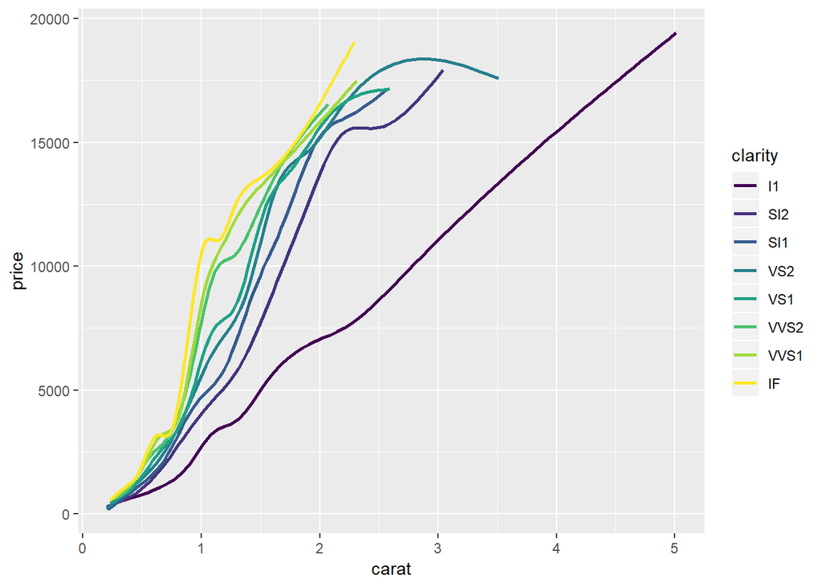

```r
dia_plot + geom_smooth(aes(col = clarity), se = FALSE)
```

-se = FALSE: No error shading.

# Data Visualization with ggplot2: Data

## Base package and ggplot2

-Base package disadvantages:

1. Plot doesn’t get redrawn.
2. Plot is drawn as a image.
3. Need to manually add legend
4. No unified framework for plotting.

-Using ggplot2

The major advantage of ggplot2 is the ggplot object. You can sign the base layers to an object, and then recycle the object with different arguements(such as different plot types).

## Plotting the ggplot2 way

- The ggplot2 way:

Rearrange the data to define variables in your dataset according to what we are really interested in. Should make the function calls as straightforward as possible.

## Tidy Data

### facet_grid(. ~ ___) It will generate several plots based on the thing you fill in the blank.

### How to rearrange your data

-‘gather()’

It moves information from the columns to the rows. It takes multiple columns and gathers them into a single column by adding rows.

Say you have a dataset like this:

```r
head(iris)
```

```
##   Sepal.Length Sepal.Width Petal.Length Petal.Width Species
## 1          5.1         3.5          1.4         0.2  setosa
## 2          4.9         3.0          1.4         0.2  setosa
## 3          4.7         3.2          1.3         0.2  setosa
## 4          4.6         3.1          1.5         0.2  setosa
## 5          5.0         3.6          1.4         0.2  setosa
## 6          5.4         3.9          1.7         0.4  setosa
```

Then if you do:

```r
library(tidyr)
iris.tidy <- iris %>%
  gather(key, Value, -Species)
```

And then have a look:

```r
 head(iris.tidy)
```

```
##   Species          key Value
## 1  setosa Sepal.Length   5.1
## 2  setosa Sepal.Length   4.9
## 3  setosa Sepal.Length   4.7
## 4  setosa Sepal.Length   4.6
## 5  setosa Sepal.Length   5.0
## 6  setosa Sepal.Length   5.4
```

So we can see that all the columns are combined except ‘species’ column(-species). All the values are now in the ‘value’ column and the column names in the previous data frame are now combined in the ‘key’ column.

-’separate()‘

It splits one column into two or more columns according to a pattern you define. So if you add another line to the previous gather command:

```r
 iris.tidy <- iris %>%
  gather(key, Value, -Species) %>%
  separate(key, c("Part", "Measure"), "\\.")
```

And then you will see:

```r
 head(iris.tidy)
```

```
##   Species  Part Measure Value
## 1  setosa Sepal  Length   5.1
## 2  setosa Sepal  Length   4.9
## 3  setosa Sepal  Length   4.7
## 4  setosa Sepal  Length   4.6
## 5  setosa Sepal  Length   5.0
## 6  setosa Sepal  Length   5.4
```

So the ‘key’ column in the previous data frame is now separated into “Part” and “Measure”. And “\.” lets the ‘key’ column separate by “.”.

-‘%>%’

It passes the result of the left-hand side as the first argument of the function on the right-hand side.

-‘spread()’

It takes two columns (key & value), and spreads into multiple columns: it makes “long” data wider.

# Data Visualization with ggplot2: Visible Aesthetics

## Typical Aesthetics

X: x axis position

y: Y axis position

colour: Colour of dots, outlines of other shapes

fill: Fill colour

size: Diameter of points, thickness of lines

alpha: Transparency

linetype: Line dash pa!ern

labels: Text on a plot or axes

shape: Shape

### shape

Shapes in R can have a value from 1-25. Shapes 1-20 can only accept a color aesthetic, but shapes 21-25 have both a color and a fill aesthetic.

The default geom_point() uses shape = 19 (a solid circle with an outline the same colour as the inside). Good alternatives are shape = 1 (hollow) and shape = 16 (solid, no outline). These all use the col aesthetic.

A really nice alternative is shape = 21 which allows you to use both fill for the inside and col for the outline.

### hexadecimal colours

Hexadecimal, literally “related to 16”, is a base-16 alphanumeric counting system. Individual values come from the ranges 0-9 and A-F. This means there are 256 possible two-digit values (i.e. 00 - FF). Hexadecimal colours use this system to specify a six-digit code for Red, Green and Blue values (“#RRGGBB”) of a colour (i.e. Pure blue: “#0000FF”, black: “#000000”, white: “#FFFFFF”). R can accept hex codes as valid colours. However, you could use “yellow” as yellow color. “red” as red.

## Modifying Aesthetics

### position = “jitter”

Add some random noise on both x and y to see regions of high density. It can be used as a argument or a function.

### Scale Function

scale_?_!(“_“, limits = *, breaks =* , expand = *, labels =* )

?: Defines which scale we want to modify(x,y,color…).

!: Match the type of data we are using(continuous or discrette).

Limits: Scale’s limits.

Breaks: controls the breaks in the guide.

Expand: is a numeric vector of two, giving a multiplicative and additive constant.

labels: label the categories.

### labs(x =*, y =*)

Quick change the axis labels.

# Data Visualization with ggplot2: Geometries

## Scatter Plot

- Each geom has specific aesthetic mappings
- geom_point()
- Essential: x, y
- Optional: alpha, colour, fill, shape, size

-example:

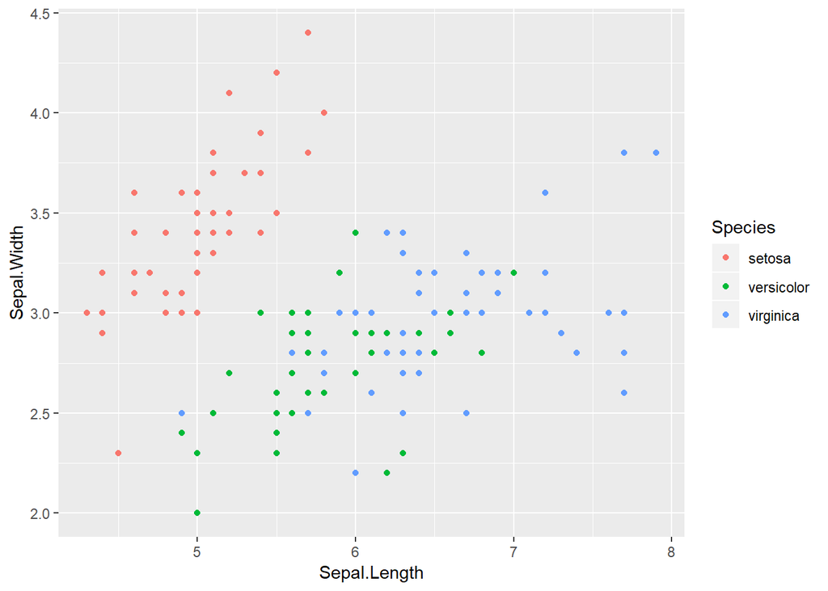

```r
 ggplot(iris, aes(x = Sepal.Length, y = Sepal.Width, col = Species)) +
 geom_point()
```

-Add layers by ‘+geom_point()’. Can modify aes inside the brackets.

-crosshair: geom_vline(data = *, linetype =* ,aes(*intercept =* , col = _))

## Bar Plots

### Histogram

-plot of statistical function

-No space between

-x axis labels between the bars

-example:

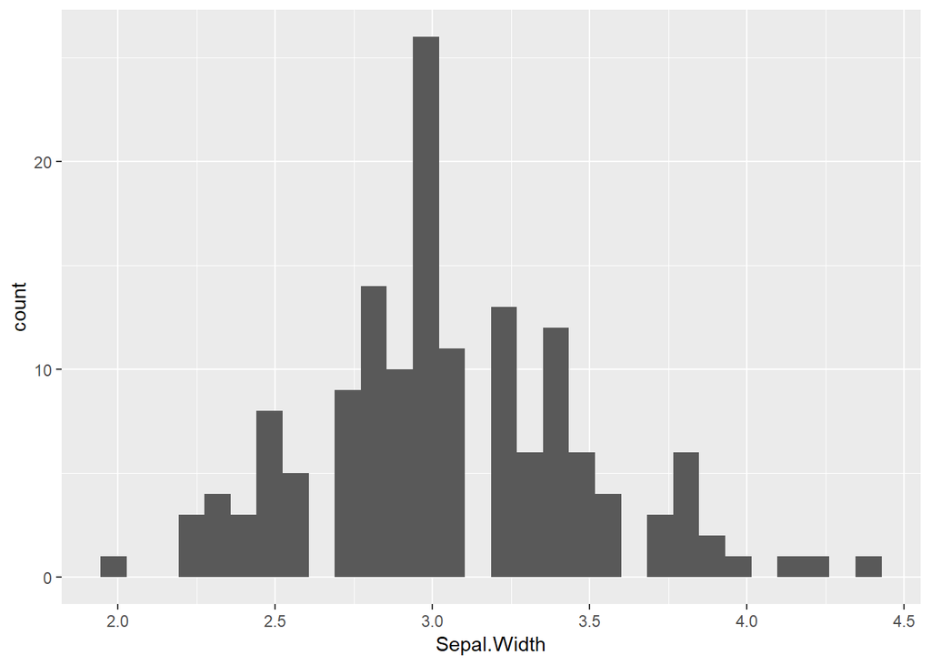

```r
ggplot(iris, aes(x = Sepal.Width)) +
geom_histogram()
```

-stat_bin: binwidth defaulted to range/30. Use ‘binwidth = x’ to adjust this:

There will always be a message like this. We can change it anytime.

Different types of ‘position’:

-stack

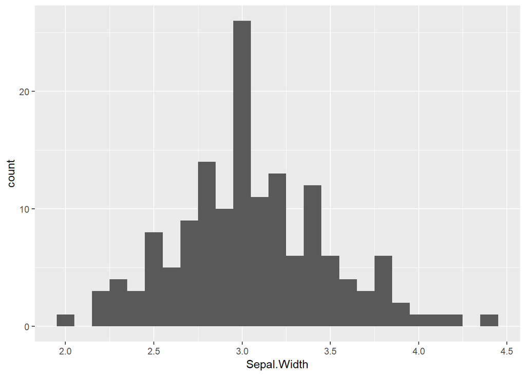

```r
ggplot(iris, aes(x = Sepal.Width )) +
geom_histogram(binwidth = 0.1,position = "stack")
```

-dodge

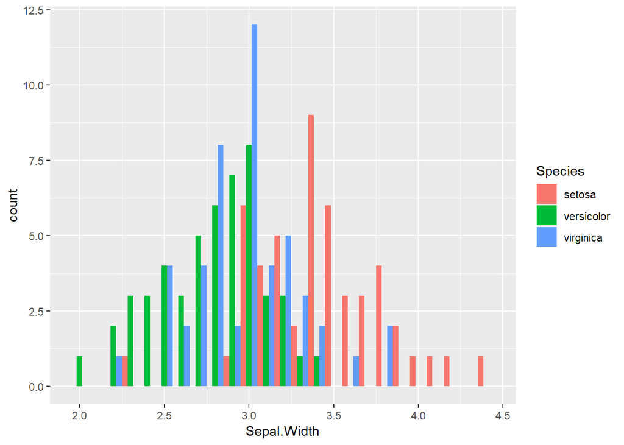

```r
ggplot(iris, aes(x = Sepal.Width, fill = Species)) +
geom_histogram(binwidth = 0.1, position = "dodge" )
```

-fill

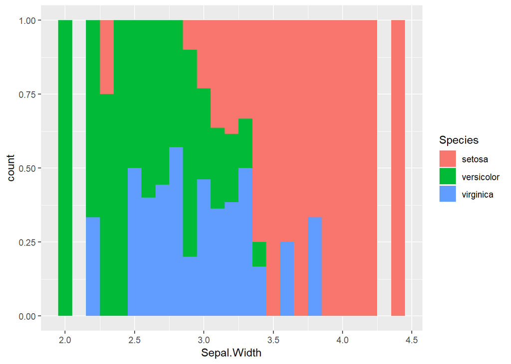

```r
ggplot(iris, aes(x = Sepal.Width, fill = Species)) +
geom_histogram(binwidth = 0.1, position = "fill" )
```

### Bar

-geom_bar()

-All positions from before available

-Two types:

Absolute counts

Distributions

-Absolute counts

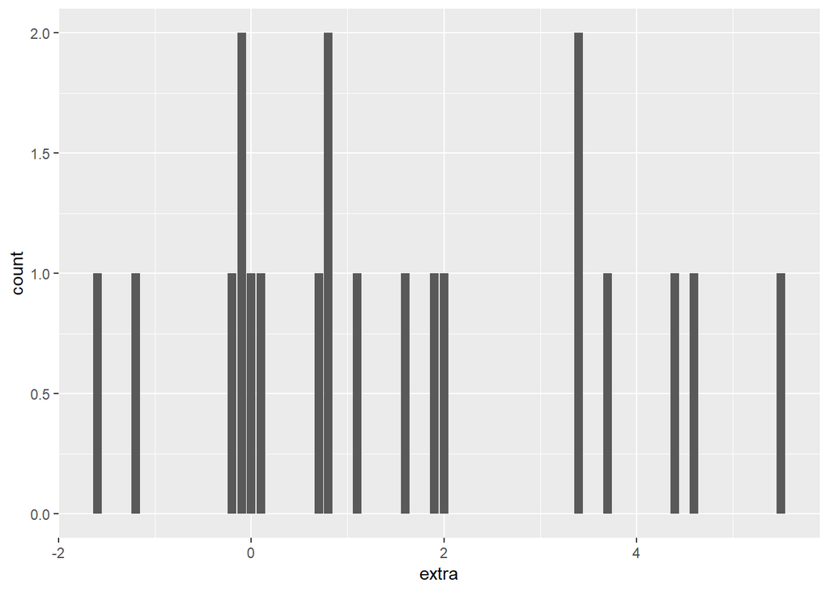

```r
ggplot(sleep, aes(extra)) +
  geom_bar()
```

-Distributions

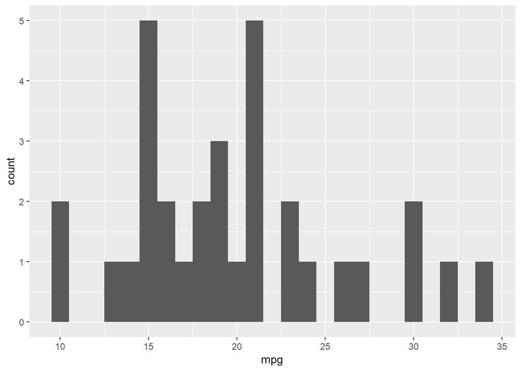

```r
ggplot(mtcars, aes(mpg, fill = cyl)) +
  geom_histogram(binwidth = 1, position = "identity")
```

-geom_errorbar geom_errorbar(aes(ymin = *, ymax =* ), width = _)

## Line plots

### geom_line

-example:

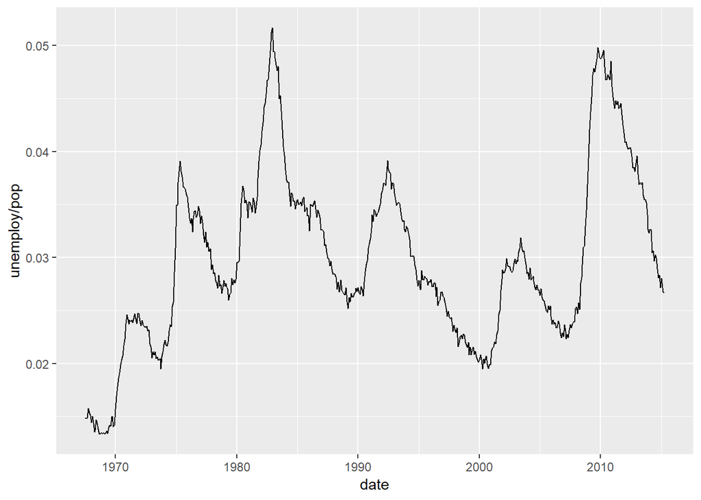

```r
ggplot(economics, aes(x = date, y = unemploy/pop)) +
  geom_line()
```

For geom_line():

There are several categorical variables:linetype, color, and size are the common choices.

### fill(geom_area)

Instead of overlapping time series, they are added together at each point.

-position = “fill”

For each time point, we have a proportion of the total y value by each category.

### geom_ribbon

ggplot(fish, aes(x = *, y =* , fill = *)) + geom_ribbon(aes(ymax =* , ymin = 0), alpha = _)